# HW5

Anish Mohan

February 13, 2017

Summary of Questions and Answers

Q1.Compare the difference of the bootstrap resampled mean of the log price of autos grouped by 1) aspiration and 2) fuel type. Use both numerical and graphical methods for your comparison. Are these means different within a 95% confidence interval? How do your conclusions compare to the results you obtained using the t-test last week?

Answer 1:

- Auto Price stratified by Aspiration:
  - Both Bootrap and T-test showed that the mean Auto price for vehicles with different aspiration is different i.e the mean price of the vechicle is dependent on the type of aspiration of the vehicle.
- Auto Price stratified by Fuel Type:
  - Both Bootrap and T-test showed that the mean Auto price for vehicles with different fuel type are not different i.e the vehicles have the same mean price independent of the fuel type

Q2. Compare the differences of the bootstrap resampled mean of the log price of the autos grouped by body style. You will need to do this pair wise; e.g. between each possible pairing of body styles. Use both numerical and graphical methods for your comparison. Which pairs of means are different within a 95% confidence interval? How do your conclusions compare to the results you obtained from the ANOVA and Tukey’s HSD analysis you performed last week?

```r
library(HistData)
library(resample)
library(simpleboot)
```

## Question 1. Bootstrap for price of Autos stratified by aspiration and fuel type

Compare the difference of the bootstrap resampled mean of the log price of autos grouped by 1) aspiration and 2) fuel type. Use both numerical and graphical methods for your comparison. Are these means different within a 95% confidence interval?

How do your conclusions compare to the results you obtained using the t-test last week?

```r
# Multi-Histogram Plotting function along with the 95% confidence lines
plot.hist = function(a, b, cols = c("Population A","Population B"), nbins = 80, p = 0.05 ){
  dat = c(a,b)
  maxs = max(dat, na.rm = TRUE)
  mins = min(dat, na.rm = TRUE)
  breaks = seq(maxs, mins, length.out = (nbins+1))
  par(mfrow = c(2,1))
  hist(a, breaks = breaks, main = paste("Histogram of ", cols[1]), xlab  = cols[1])
  abline(v = mean(a), lwd = 4, col = "red")

  if(p!=0){
    abline(v = quantile(a, probs = p/2), lty = 3, col = "red", lwd = 3)
    abline(v = quantile(a, probs = (1-p/2)), lty = 3, col = "red", lwd = 3)
  }

  hist(b, breaks = breaks, main = paste("Histogram of ", cols[2]),  xlab = cols[2])
  abline(v = mean(b), lwd = 4, col = "red")
  if(p!=0){
    abline(v = quantile(b, probs = p/2), lty = 3, col = "red", lwd = 3)
    abline(v = quantile(b, probs = (1-p/2)), lty = 3, col = "red", lwd = 3)
  }
}


plot.hist2 = function(a, cols = c("Population A"), nbins = 80, p = 0.05 ){
  dat = c(a)
  maxs = max(dat, na.rm = TRUE)
  mins = min(dat, na.rm = TRUE)
  breaks = seq(maxs, mins, length.out = (nbins+1))
  par(mfrow = c(1,1))
  hist(a, breaks = breaks, main = paste("Histogram of ", cols[1]), xlab  = cols[1])
  abline(v = mean(a), lwd = 4, col = "red")

  if(p!=0){
    abline(v = quantile(a, probs = p/2), lty = 3, col = "red", lwd = 3)
    abline(v = quantile(a, probs = (1-p/2)), lty = 3, col = "red", lwd = 3)
  }
}
```

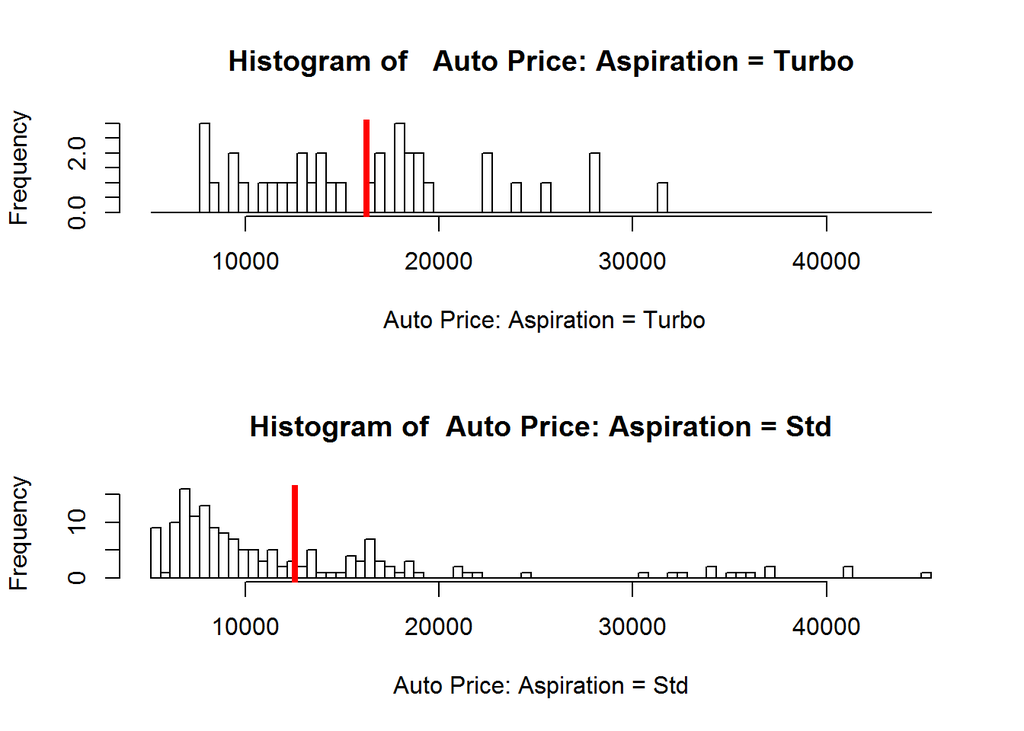

```r
#Comparing  Log(Price) v.s Aspiration
auto.turbo.log.price = (auto[auto$aspiration=="turbo",]$price)
auto.std.log.price = (auto[auto$aspiration == "std",]$price)
plot.hist(auto.turbo.log.price, auto.std.log.price, c(" Auto Price: Aspiration = Turbo", "Auto Price: Aspiration = Std"), p = 0)
```

```r
#T-test
t.test(auto.turbo.log.price, auto.std.log.price, alternative = "two.sided")
```

```
##
##  Welch Two Sample t-test
##
## data:  auto.turbo.log.price and auto.std.log.price
## t = 3.0181, df = 66.866, p-value = 0.003598
## alternative hypothesis: true difference in means is not equal to 0
## 95 percent confidence interval:
##  1248.683 6126.462
## sample estimates:
## mean of x mean of y
##  16254.81  12567.23
```

The t-test shows that the p-value = 0.0036 which is smaller than the significance leve of 0.05. Hence we can reject the null hypothesis that the mean of the Auto price is same for Autos with Turbo and Std aspriation. Hence the mean values for these two classes of the autos are different.

### Bootstrap for Auto Price on Aspiration

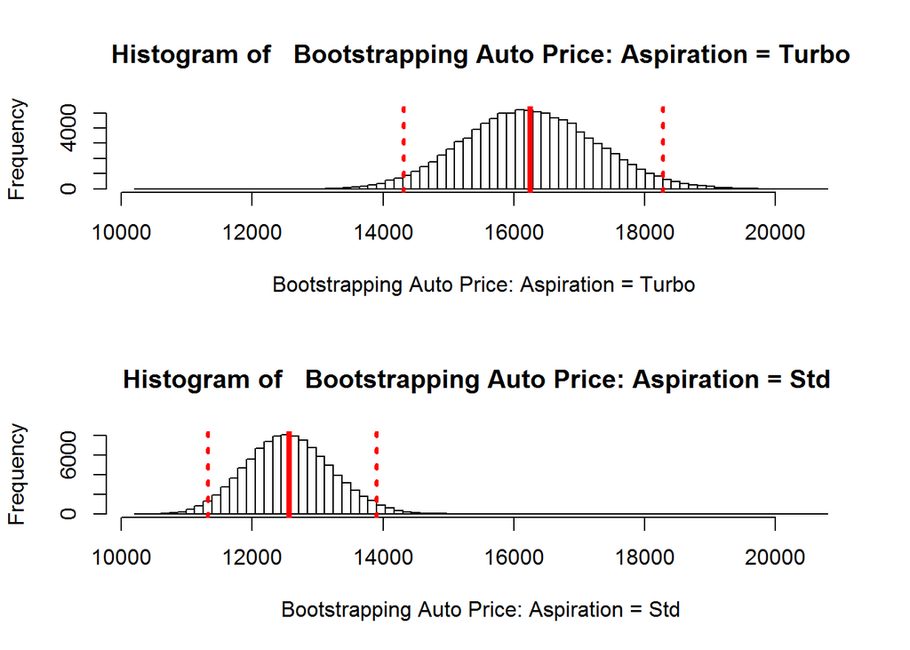

```r
#Bootstrap
mean.boot.auto.turbo.price = one.boot(auto.turbo.log.price, mean, R = 100000)
mean.boot.auto.std.price = one.boot(auto.std.log.price, mean, R = 100000)
plot.hist(mean.boot.auto.turbo.price$t, mean.boot.auto.std.price$t, c(" Bootstrapping Auto Price: Aspiration = Turbo", " Bootstrapping Auto Price: Aspiration = Std "))
```

```r
print(paste0("Mean value of Auto Price with Aspiration = Turbo given by Bootstrap: $",mean.boot.auto.turbo.price$t0))
```

```
## [1] "Mean value of Auto Price with Aspiration = Turbo given by Bootstrap: $16254.8055555556"
```

```r
print(paste0("Mean value of Auto Price with Aspiration = Std given by Bootstrap: $",mean.boot.auto.std.price$t0))
```

```
## [1] "Mean value of Auto Price with Aspiration = Std given by Bootstrap: $12567.2327044025"
```

Bootrapped values show that the 95% interval for bootstrapped values of the mean do not overlap hence we can conclude that the mean Auto price for vehicles with different aspiration is different

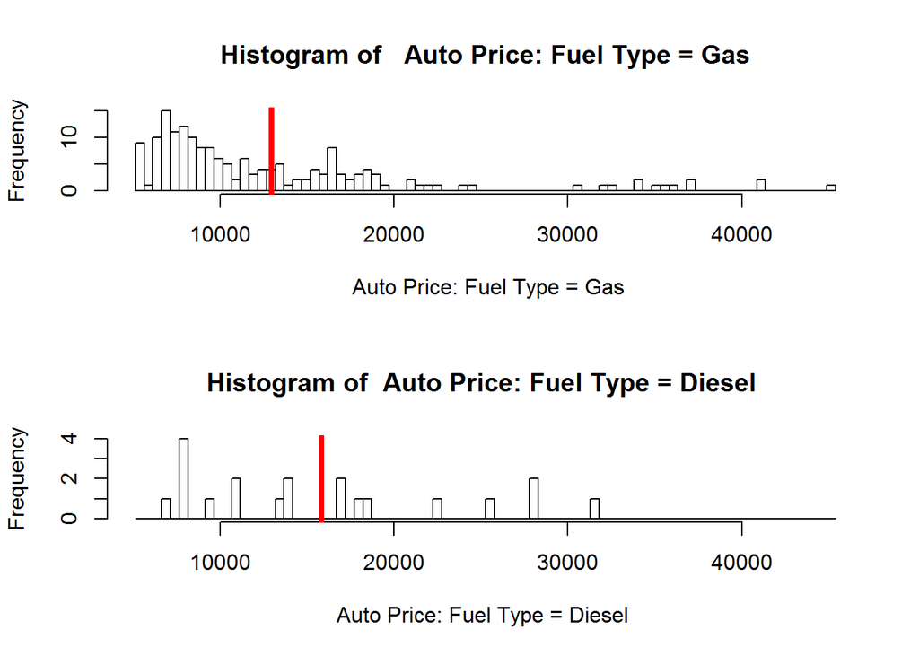

```r
#Comparing  Log(Price) vs. Fuel Type
auto.gas.log.price = (auto[auto$fuel.type=="gas",]$price)
auto.diesel.log.price = (auto[auto$fuel.type == "diesel",]$price)
plot.hist(auto.gas.log.price, auto.diesel.log.price, c(" Auto Price: Fuel Type = Gas", "Auto Price: Fuel Type = Diesel "), p = 0)
```

```r
#T-test
t.test(auto.gas.log.price, auto.diesel.log.price, alternative = "two.sided")
```

```
##
##  Welch Two Sample t-test
##
## data:  auto.gas.log.price and auto.diesel.log.price
## t = -1.5694, df = 23.932, p-value = 0.1297
## alternative hypothesis: true difference in means is not equal to 0
## 95 percent confidence interval:
##  -6682.1579   909.8579
## sample estimates:
## mean of x mean of y
##  12952.00  15838.15
```

### Bootstrap for Auto Price on Fueltype

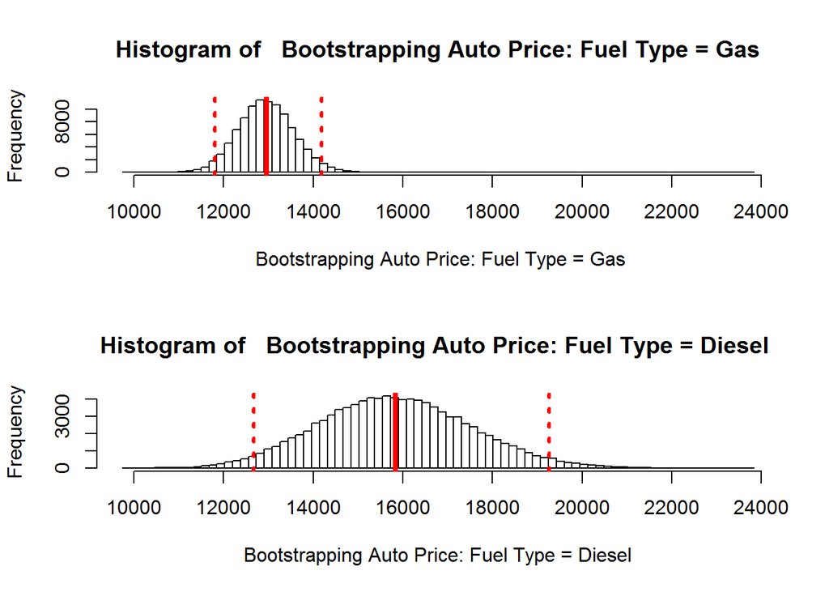

```r
#Bootstrap
mean.boot.auto.gas.price = one.boot(auto.gas.log.price, mean, R = 100000)
mean.boot.auto.diesel.price = one.boot(auto.diesel.log.price, mean, R = 100000)
plot.hist(mean.boot.auto.gas.price$t, mean.boot.auto.diesel.price$t, c(" Bootstrapping Auto Price: Fuel Type = Gas", " Bootstrapping Auto Price: Fuel Type = Diesel "))
```

```r
print(paste0("Mean value of Auto Price with fuel = Gas given by Bootstrap: $",mean.boot.auto.gas.price$t0))
```

```
## [1] "Mean value of Auto Price with fuel = Gas given by Bootstrap: $12952"
```

```r
print(paste0("Mean value of Auto Price with fuel = Diesel given by Bootstrap: $",mean.boot.auto.diesel.price$t0))
```

```
## [1] "Mean value of Auto Price with fuel = Diesel given by Bootstrap: $15838.15"
```

Bootrapped values show that the 95% interval for bootstrapped values of the mean overlap hence we can conclude that the mean Auto price for vehicles with different fuel type are not different

## Question 2. Bootstrap for price of Autos stratified by Body style

### Analysis of Variance for price of Autos stratified by Body style

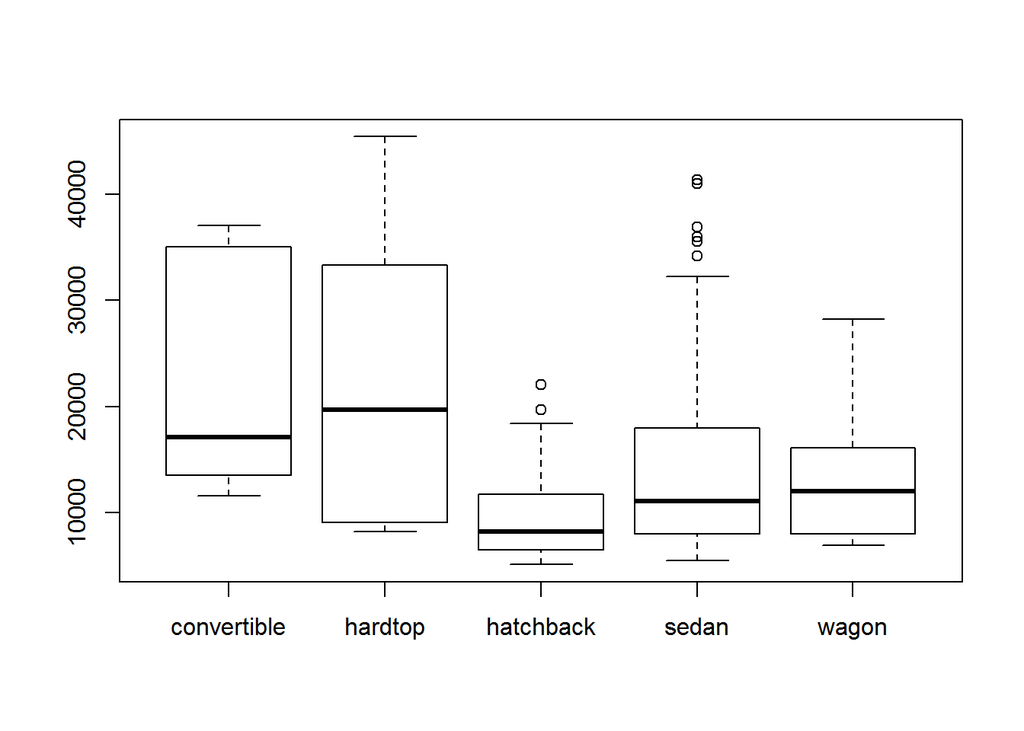

```r
# Analysis of variance
boxplot(price~body.style, data = auto)
```

```r
auto.body.aov = aov(price ~ as.factor(body.style), data = auto)
summary(auto.body.aov)
```

```
##                        Df    Sum Sq   Mean Sq F value   Pr(>F)
## as.factor(body.style)   4 2.007e+09 501661379   9.005 1.11e-06 ***
## Residuals             190 1.058e+10  55709572
## ---
## Signif. codes:  0 '***' 0.001 '**' 0.01 '*' 0.05 '.' 0.1 ' ' 1
```

```r
print(auto.body.aov)
```

```
## Call:
##    aov(formula = price ~ as.factor(body.style), data = auto)
##
## Terms:
##                 as.factor(body.style)   Residuals
## Sum of Squares             2006645518 10584818669
## Deg. of Freedom                     4         190
##
## Residual standard error: 7463.885
## Estimated effects may be unbalanced
```

The Analysis of Variance based on body.style gives a p-value of < 1.11e-06, hence we can reject the null-hypotheses and specify that there are significant differences in price dependent on the body style

### Tukey’s Honest Significant Difference test for price of Autos stratified by Body style

```r
tukey.body.anova = TukeyHSD(auto.body.aov)
tukey.body.anova
```

```
##   Tukey multiple comparisons of means
##     95% family-wise confidence level
##
## Fit: aov(formula = price ~ as.factor(body.style), data = auto)
##
## $`as.factor(body.style)`
##                             diff        lwr          upr     p adj
## hardtop-convertible      318.000 -10783.871 11419.871137 0.9999912
## hatchback-convertible -12126.516 -20909.284 -3343.747520 0.0017866
## sedan-convertible      -7430.745 -16086.665  1225.175259 0.1297690
## wagon-convertible      -9390.333 -18773.127    -7.539706 0.0497064
## hatchback-hardtop     -12444.516 -20160.062 -4728.969444 0.0001460
## sedan-hardtop          -7748.745 -15319.583  -177.906765 0.0419991
## wagon-hardtop          -9708.333 -18100.559 -1316.107586 0.0143955
## sedan-hatchback         4695.771   1348.673  8042.869032 0.0014261
## wagon-hatchback         2736.183  -2194.835  7667.199697 0.5454424
## wagon-sedan            -1959.589  -6660.957  2741.779260 0.7807015
```

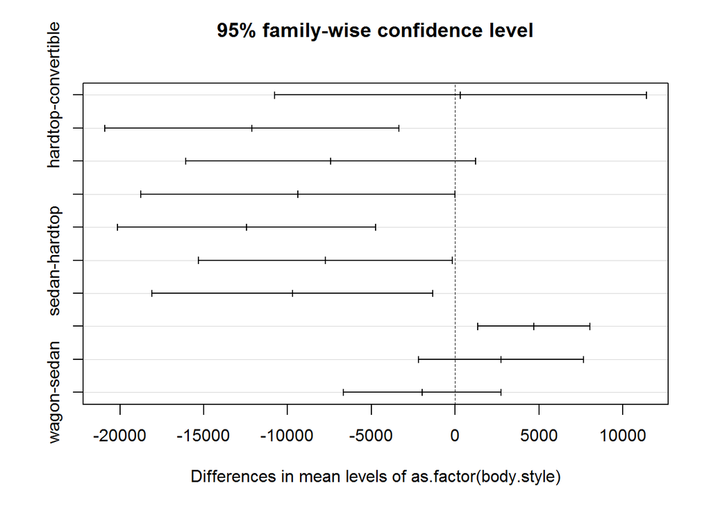

```r
plot(tukey.body.anova)
```

Some p-values are low indicating significant differences in the price dependent on the body style Following pairs have significanly different prices:

- Hatchback and Convertible
- Wagon and Convertible
- Hatchback and Hardtop
- Sedan and Hardtop
- Wagon and Hardtop
- Sedan and Hatchback.

```r
auto.convertible.price = log(auto[auto$body.style =="convertible",]$price)
auto.hardtop.price = log(auto[auto$body.style =="hardtop",]$price)
auto.hatchback.price = log(auto[auto$body.style =="hatchback",]$price)
auto.sedan.price = log(auto[auto$body.style =="sedan",]$price)
auto.wagon.price = log(auto[auto$body.style =="wagon",]$price)
```

## Bootstrap for price of Autos stratified by Body style

```r
mean.twoboot.auto.convertible.hardtop = two.boot(auto.convertible.price, auto.hardtop.price,mean, R = 100000)
mean.twoboot.auto.convertible.hatchback =two.boot(auto.convertible.price, auto.hatchback.price, mean, R = 100000)
mean.twoboot.auto.convertible.sedan = two.boot(auto.convertible.price, auto.sedan.price,mean, R = 100000)
mean.twoboot.auto.convertible.wagon = two.boot(auto.convertible.price, auto.wagon.price,mean, R = 100000)

mean.twoboot.auto.hatchback.hardtop = two.boot(auto.hatchback.price, auto.hardtop.price,mean, R = 100000)
mean.twoboot.auto.sedan.hardtop = two.boot(auto.sedan.price, auto.hardtop.price,mean, R = 100000)
mean.twoboot.auto.wagon.hardtop = two.boot(auto.wagon.price, auto.hardtop.price,mean, R = 100000)

mean.twoboot.auto.hatchback.sedan = two.boot(auto.hatchback.price, auto.sedan.price,mean, R = 100000)
mean.twoboot.auto.hatchback.wagon = two.boot(auto.hatchback.price, auto.wagon.price,mean, R = 100000)

mean.twoboot.auto.sedan.wagon = two.boot(auto.wagon.price, auto.wagon.price,mean, R = 100000)
```

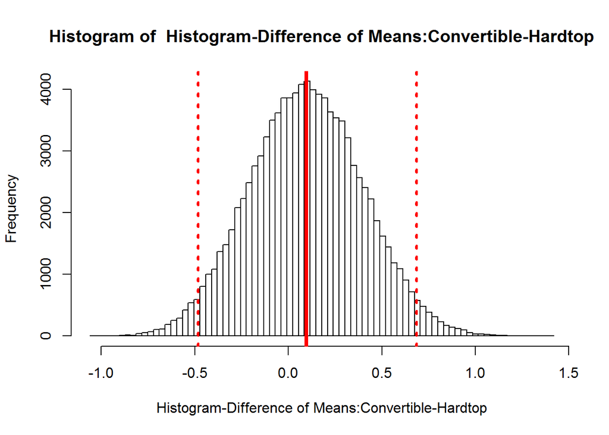

```r
#Convertible vs Hardtop
plot.hist2(mean.twoboot.auto.convertible.hardtop$t, c("Histogram-Difference of Means:Convertible-Hardtop"))
```

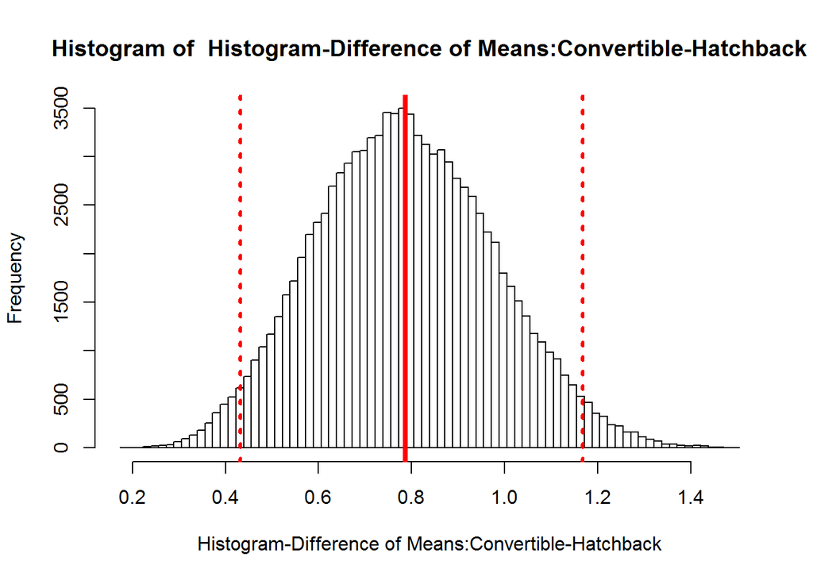

```r
#Convertible vs Hatchback
plot.hist2(mean.twoboot.auto.convertible.hatchback$t, c("Histogram-Difference of Means:Convertible-Hatchback"))
```

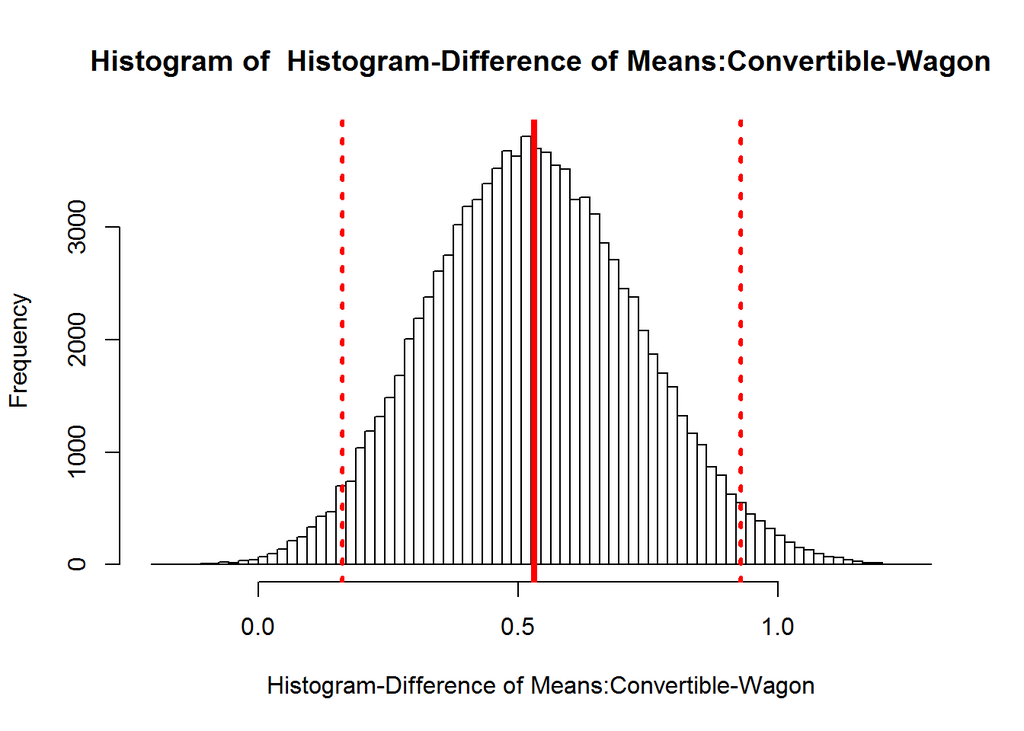

```r
#Convertible vs Wagon
plot.hist2(mean.twoboot.auto.convertible.wagon$t, c("Histogram-Difference of Means:Convertible-Wagon"))
```

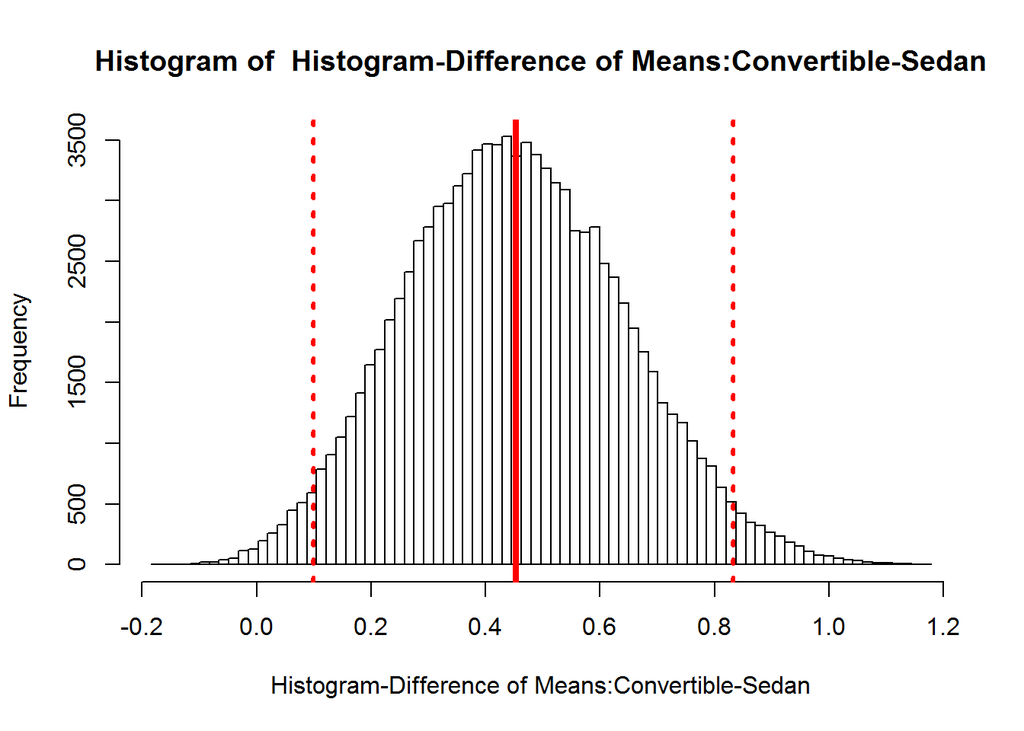

```r
#Convertible vs Sedan
plot.hist2(mean.twoboot.auto.convertible.sedan$t, c("Histogram-Difference of Means:Convertible-Sedan"))
```

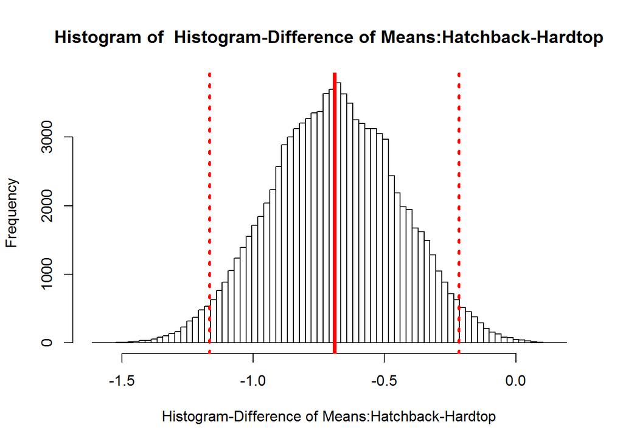

```r
#Hardtop vs Hatchback
plot.hist2(mean.twoboot.auto.hatchback.hardtop$t, c("Histogram-Difference of Means:Hatchback-Hardtop"))
```

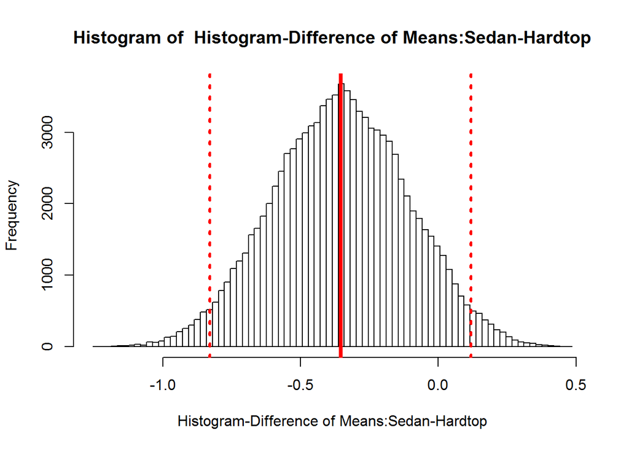

```r
#Hardtop vs Sedan
plot.hist2(mean.twoboot.auto.sedan.hardtop$t, c("Histogram-Difference of Means:Sedan-Hardtop"))
```

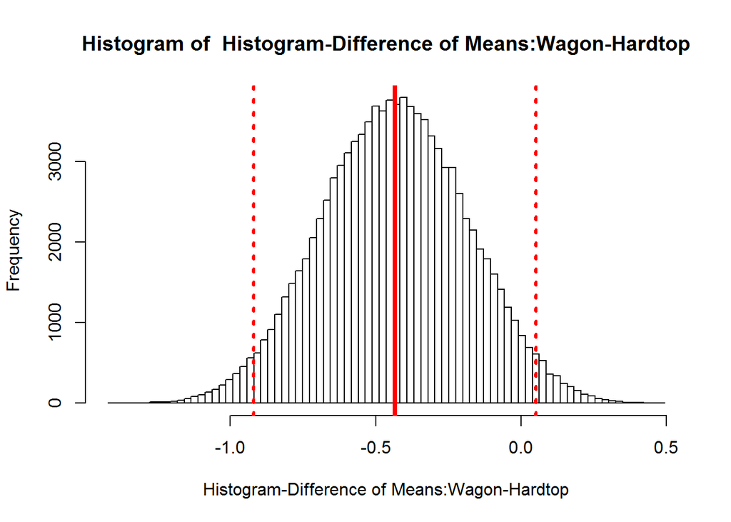

```r
#Hardtop vs Wagon
plot.hist2(mean.twoboot.auto.wagon.hardtop$t, c("Histogram-Difference of Means:Wagon-Hardtop"))
```